# INFO 201 Project

Alison Chua, Zeynep Usta, Allison Chang, Amanda Chin

2024-03-05

```r
library(readr)
library(dplyr)
library(tidyverse)
library(stringr)
library(ggplot2)
```

## Introduction

Understanding the factors behind a movie’s success can provide insight into market trends, audience behavior, and financial considerations for future movies. This information can be crucial for filmmakers, producers, and stakeholders in the film and entertainment industry.

From our pre-existing knowledge of the film industry, we know that a variety of factors can impact a movie’s success. We know that the Western hemisphere typically dominates the film industry and most films consumed depict Western culture and societal norms. Additionally, from seeing the success of previous films, we know that a movie’s budget does not necessarily dictate its success. Many films in the past have had minimal success even with a higher budget and a star-studded cast. Furthermore, we also know that a movie’s content classification can play a big role in its marketing strategy and target audience and might even affect its revenue and profit generation. To discover more about the factors that influence a movie’s success, we merged two data sets we found on Kaggle: “IMDB Movies” and “Rotten Tomatoes Movies Database” and added a new categorical and numerical variable, continent and profit. Using this merged dataset, we aimed to answer these research questions:

1. How does the studio of a movie affect its popularity?
2. Does the continent a movie is aired at, affect its user rating?
3. How does a movie’s budget affect its profit?
4. Does a movie’s age restrictive rating affect its revenue?

Understanding the factors that affect a movie’s success can hold practical implications for various stakeholders in the film and entertainment industry. Recognizing the effects of content classification can offer insight into audience trends and marketing strategies. Analyzing if the studio a movie is produced in affects its success is also critical to understanding marketing strategies and the implications of branding. Financially speaking, the relationship between a movie’s budget and its profitability can provide crucial information for financial planning and can guide producers and filmmakers in making cost-effective decisions. Additionally, films tailored with the audience tastes and preferences in mind can result in a more engaging and satisfying experience for viewers. Overall, understanding the dynamics behind a movie’s success can provide insight into marketing strategies, audience trends, and cost-effective decisions in the film industry.

## Overview of Our Data

In current society, movies play a vital role in entertainment, cultural representation, and even societal reflection. Understanding the dynamics influencing movie success is crucial for filmmakers, producers, and investors. In this analysis, we explore the complex realm of movie success, examining the relationship between various factors such as region, studio, age restriction, and budget, and their impact on revenue and user ratings. Using datasets from renowned movie review platforms, IMDB and Rotten Tomatoes, we aim to gain insights into the factors influencing movie success and audience reception.

The datasets we used for our analysis stems were “IMDB Movies” and “Rotten Tomatoes Movies” datasets sourced from Kaggle that are public and the data is downloadable. The datasets originate from two movie review platforms, IMDB and Rotten Tomatoes, which serve as hubs for movie enthusiasts and critics to share their opinions and evaluations. We chose these datasets because IMDB and Rotten Tomatoes are currently two of the most popular movie review databases and this allows for a more relevant and accurate representation of our analysis. The “IMDB Movies Dataset” was compiled by user Asphal Singh from the IMDB database onto Kaggle. Likewise, the “Rotten Tomatoes” dataset was collected by user Ayush Kalia from the Rotten Tomatoes database onto Kaggle. Both datasets offer invaluable insights into the world of cinema, providing detailed information on variables such as budget, region, revenue, runtime, and user ratings. The census is collected by obtaining information about movies and user ratings from various sources and databases. This data collection process allows for a thorough understanding of movie trends and audience preferences.

These datasets are easy to access and use for analysis, without any specific restrictions on who can access them or how they can be used. Both the IMDB and Rotten Tomatoes datasets are freely available to everyone, enabling unrestricted exploration and analysis. Moreover, the data usage permissions do not pose any ethical concerns, as the datasets exclusively contain movie-related information and do not involve private or confidential data.

The IMDB dataset is a repository of movie information containing important variables such as movie titles, user ratings, movie budget, movie revenue, and region of release. To increase the reliability of our analysis, we cross-referenced this dataset with data from Rotten Tomatoes, another highly rated source in the movie review domain. By using data from both platforms, we aim to validate the accuracy of our data and find whether or not certain variables affect movie success. Additionally, as part of our data cleaning process, we standardized variable names across both datasets to ensure consistency.

The Rotten Tomatoes dataset we utilized includes variables such as rating, genre, studio, title, and release year. During data cleaning, we encountered challenges with the genre column, which was separated individually by genre, resulting in instances where movies had multiple entries if they belonged to more than one genre. To resolve this issue and prevent a many-many relationship when merging datasets, we aggregated the data by movie title and merged the genres together. This approach ensured that information about each movie was consolidated into a single row, avoiding duplication. Unlike the IMDB dataset, the Rotten Tomatoes dataset did not include scores but provided additional information such as studio and age restriction rating. This expanded dataset allows for a more comprehensive analysis by incorporating additional variables from another reliable source.

IMDB link: https://www.kaggle.com/datasets/ashpalsingh1525/imdb-movies-dataset

Rotten Tomatoes link: https://www.kaggle.com/datasets/ayushkalla1/rotten-tomatoes-movie-database

## Discuss our Methods

The variables that we used were movie title, popularity/user rating, budget, runtime, revenue, country, release date, vote average, release continent, and revenue. We thought that these variables were what was going to showcase exactly what affects how well a movie does in the eyes of the public. There are many different factors that may impact the success of a movie and we thought these were the most important decisions that our audience have to tackle before starting the pre-production process.

We processed our data by reading through csv files that held our data. We then used the select() function in order to keep the specific variables that we wanted to visualize and analyze. In the IMDB file, there were several observations of the same movie within the dataset with the only differences being the budget and revenue values, so, in order to get rid of the duplicates, we grouped by the names of the movies, and used the mutate function in order to take the means of the corresponding columns. And finally, to make sure there were truly no duplicates in our dataset, we used the unique function. For the rotten tomatoes data set, we also had to clean up the data in a similar way because there were also duplicates of the same movie, but the dataset had broken up the different genres of a movie into several different rows. In order to condense those values, we selected the specific rows we wanted, and then grouped by the Title, and mutated the genre row by pasting the unique values together with a comma. That allowed us to remove any repeated values.

We selected the sample based on the samples that were given to us by each of the datasets and then we narrowed our sample size even further by merging the datasets together by the inner_join function in order to join each of the dataset by their common values. The sample size goes down even further from that.

```r
# Loading datasets
imdb <- read_delim("project/imdb_movies.csv")
rt <- read_delim("project/rotten_tomatoes.csv")
```

```r
## Cleaning up data
### Selecting data
## IMDB
imdb <- imdb %>%
  select(names, budget_x, revenue, country, score) %>%
  mutate(score = score/10) %>%
  group_by(names) %>%
  mutate(budget_x = mean(budget_x, na.rm = TRUE), revenue = mean(revenue, na.rm = TRUE))
imdb <- unique(imdb)
names(imdb) <- c("title", "budget", "revenue", "region", "imdb_vote_avg")
## Rotten tomatoes
rt <- rt %>%
  select(Rating, Studio, Runtime, Genre, Title, Year) %>%
  mutate(Runtime = as.double(sub(" minutes", "", Runtime))) %>%
  group_by(Title) %>%
  mutate(Genre = paste(unique(Genre), collapse = ", ")) %>%
  slice(1) %>%
  ungroup()
names(rt) <- c("rating", "studio", "runtime", "genre", "title", "year")
```

```r
## Merging data together
merged_data <- inner_join(imdb, rt)
```

```r
### Add column: profit
merged_data <- merged_data %>%
  mutate(profit = revenue - budget)
```

```r
## adding continent variable
merged_data <- merged_data %>%
  mutate(continent = ifelse(region == "FR" | region == "GB" | region == "ES" |
                              region == "IT" | region == "DE" | region == "RU" |
                              region == "DK" | region == "PL" | region == "TR" |
                              region == "NO" | region == "NL" | region == "IE" |
                              region == "SE" | region == "BE" | region == "FI" |
                              region == "GR" | region == "SU" | region == "UA" |
                              region == "HU" | region == "IS" | region == "CZ" |
                              region == "SK" | region == "AT" | region == "BY" |
                              region == "LV" | region == "XC" | region == "PT", "Europe",
                      ifelse(region == "JP" | region == "KR" | region == "HK" |
                               region == "CN" | region == "PH" | region == "IN" |
                               region == "TH" | region == "SG" | region == "VN" |
                               region == "MY" | region == "IR" | region == "IL" |
                               region == "TW" | region == "ID" | region == "KH",
                             "Asia",
                      ifelse(region == "US" | region == "MX" | region == "CA" |
                               region == "PR" | region == "DO" | region == "GT",
                             "North America",
                      ifelse(region == "AR" | region == "BR" | region == "CO" |
                               region == "CL" | region == "PE" | region == "UY" |
                               region == "BO" | region == "PY",
                             "South America",
                      ifelse(region == "ZA" | region == "MU", "Africa",
                      ifelse(region == "AU", "Australia", NA)))))))
```

## How does the studio of a movie affect its popularity?

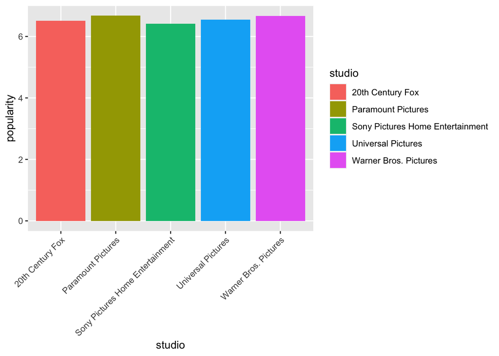

```r
merged_data %>%
  filter(studio == "Warner Bros. Pictures" | studio == "Paramount Pictures" |
           studio == "Universal Pictures" | studio == "20th Century Fox" |
           studio == "Sony Pictures Home Entertainment") %>%
  group_by(studio) %>%
  summarize(popularity = mean(imdb_vote_avg)) %>%
  ggplot(aes(studio, popularity, fill = studio)) +
  geom_col() +
  theme(axis.text.x = element_text(angle = 45, hjust = 1))
```

## Does the continent a movie is aired at, affect its user rating?

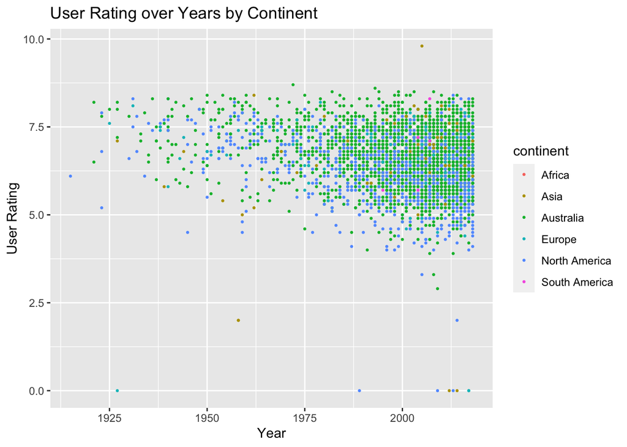

```r
merged_data %>%
  filter(!is.na(continent)) %>%
  ggplot(aes(year, imdb_vote_avg, color = continent)) +
  geom_point(size = 0.5) +
  labs(title = "User Rating over Years by Continent",
       x = "Year",
       y = "User Rating",
       fill = "Continents")
```

## How does a movie’s budget affect its profit?

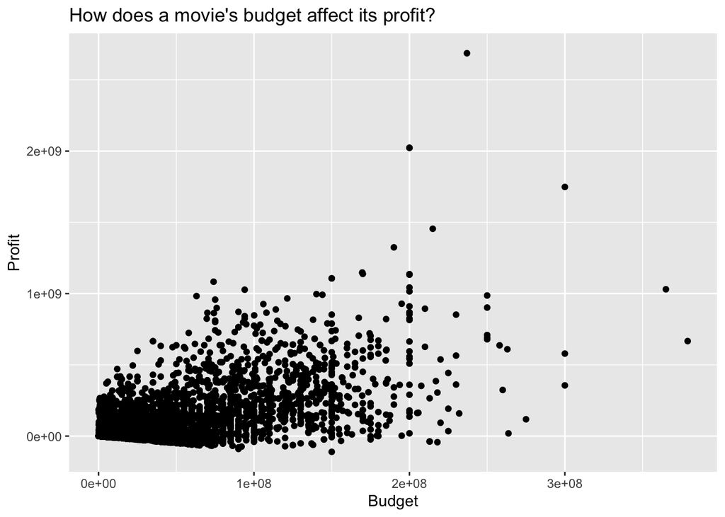

```r
merged_data %>%
  ggplot(aes(budget, profit)) +
  geom_point() +
  labs(x = "Budget",
       y = "Profit",
       title = "How does a movie's budget affect its profit?")
```

## Does a movie’s age restrictive rating affect its revenue?

```r
avg_revenue <- merged_data %>%
  mutate(rating = str_replace_all(rating, "\\s+","")) %>% #deletes any extra spacing in rating names to make them all equal
  group_by(rating) %>%
  summarize(avg = mean(revenue, na.rm = TRUE)) #finds average revenue per rating

avg_revenue
```

```
## # A tibble: 6 × 2
##   rating        avg
##   <chr>       <dbl>
## 1 G      228910647.
## 2 NC17   144320544.
## 3 NR     234255828.
## 4 PG     174189109.
## 5 PG-13  192632282.
## 6 R      103427691.
```

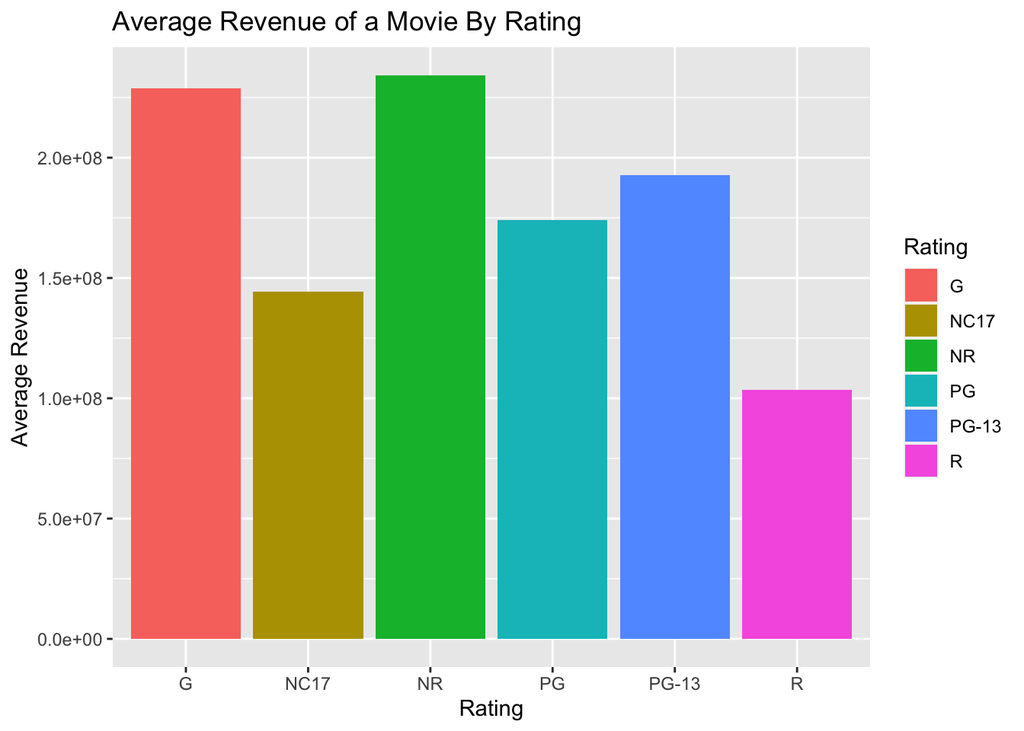

```r
avg_revenue %>%
  ggplot(aes(rating, avg, fill = rating)) +
  geom_col() +
  labs(title = "Average Revenue of a Movie By Rating",
       x = "Rating",
       y = "Average Revenue",
       fill = "Rating")
```

## Findings

There are certain limitations to our datasets and overall topic, as movie production is a rather recent process that has not been around for long. We can only observe data from a relatively short time period, with earlier years having limited data when movies were first starting out. Additionally, not all movies are included in these datasets that we merged, so we were only able to make observations and conclusions about a sample of the overall target data. This means that our data and findings may not necessarily be the best representation of all movies produced. Also, as there are several factors that affect a movie’s outcome and popularity, which even includes subjective variables such as the varied opinions of users, it is difficult to make causal claims even if a relationship between variables is observed. We can merely show any possible correlations between variables and speculate based on these visuals.